# FAQs and example for project

Dr. Kelly R. Moran

6/16/2020

## Project FAQs

#### Should I be using the same questions as I used in my proposal?

You are welcome to use these questions as a starting point, so long as you tweak them so they are appropriate for the type of analyses you will do in this project! You may also choose to focus in on one of your questions from the proposal, and use it as the basis for both inferential questions you’ll address in this project. Remember, one of your questions should lend itself to being answered with inference, and one should lend itself to being answered with multiple linear regression.

#### Do I need to include the word ‘significant’ in my question?

No! Most research papers ask about relationships. Significance is one aspect of the story that is told about a relationship, but so are the direction and magnitude of that relationship.

If you ask a question like “Is there a relationship between x and y?”, you will of course end up reporting the significance of observed relationships. But you will first visually explore said relationship. How exactly does x seem to impact y? How big is that impact? Is it what you expected? Then you’ll get to significance. But asking the question “Is there a *significant* relationship between x and y?” right off the bat implies that significance is the end-all-be-all, or the entire point of the research… and it isn’t.

#### What if my data are super right-skewed?

Try a log transformation prior to performing regression or inference! Remember you’ll have to adjust your interpretations when talking about things like the difference in means or the meaning of coefficients in a regression. See [this resource](https://data.library.virginia.edu/interpreting-log-transformations-in-a-linear-model/) for a great explanation of how to interpret your ouput in the case of log transformation of the explanatory and/or response variables.

#### What if the test/procedure I want to do has a normality assumption but my data don’t seem normal enough for inference?

The `inference` function has a `method="simulation"` argument that allows you to perform bootstrapping rather than getting theoretical results. That is, if conditions for are violated you can still perform inference.

For ANOVA and regression, if even after transforming (e.g., via the log transform) you see violations of normality (or issues with your residual plots) just make note of these and discuss what tells you there may be cause for concern – I don’t expect you to solve all of these data issues!

## Partial example with commentary

```r
# Load data
load(url("https://www.openintro.org/data/rda/ncbirths.rda"))
```

### Introduction

*Here I would first introduce the data set (as you all did in your proposals).*

*Now I would build up to why I should care about the research questions to follow (you could also structure your project by putting this after the questions themselves). E.g., for me I would talk about how birthweight is linked to a lot of health outcomes for the infant, and is tied to some details of the mother/pregnancy– I would cite sources here.*

*Then I would introduce my inferential and regression questions. You can use one or both questions from your proposal if they are able to be answered by inference/regression, though you will likely have to tweak the wording somewhat. These questions need not be tied to the same outcome variable, but you will likely have an easier time with the flow of your story if they are. I include an example of a couple of questions below.*

1. Is there a difference in neonatal birth weight between babies born to smoking and non-smoking mothers?

*Talk about my hypothesis. E.g., babies born to smoking mothers will weigh less than those born to nonsmoking mothers because [citation].*

2. More broadly, what are the predictive factors of neonatal birth weight for mothers in North Carolina?

*Talk about my hypothesis. E.g., longer gestation will naturally increase birthweight, race of mother will… [citation].*

### Exploratory data analysis

Remember, we want to tell a story with our EDA. My main variable of interest is birthweight, and both my questions center around understanding the relationship between birthweight and other variables in the data set. To begin, I would look at birthweight on its own.

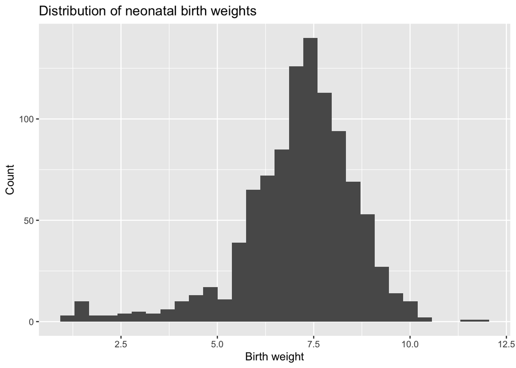

```r
# Plot histogram of birthweight
ggplot(ncbirths, aes(x=weight)) +
  geom_histogram() +
  ylab('Count') +
  xlab('Birth weight') +
  ggtitle('Distribution of neonatal birth weights')
```

```r
# Numerically summarize birthweight on its own
ncbirths %>%
  summarise(mean_bw=mean(weight),
            med_bw=median(weight),
            sd_bw=sd(weight),
            iqr_bw=IQR(weight),
            n_obs=n())
```

```
## # A tibble: 1 x 5
##   mean_bw med_bw sd_bw iqr_bw n_obs
##     <dbl>  <dbl> <dbl>  <dbl> <int>
## 1    7.10   7.31  1.51   1.68  1000
```

The distribution of birthweight is unimodal. The weights are left skewed, and the typical observation is 7.31 pounds, which is slightly higher than the mean (7.1 pounds) due to the left skewness. The middle 50% of observations have a spread of 1.68 pounds, and the standard deviation is 1.51 pounds. *I could also further discuss why the data may be left skewed (there’s a “cap” at which babies really can’t weigh more, but premature babies can be quite underweight).*

*Now I would move on to EDA relevant to my first question (the inference question). Since this question is about seeing if there is a difference in birth weight for mothers having smoking vs. nonsmoking status, I would want numeric and visual summaries that could let me qualitatively explore that before I moved on to formal testing in the next section.*

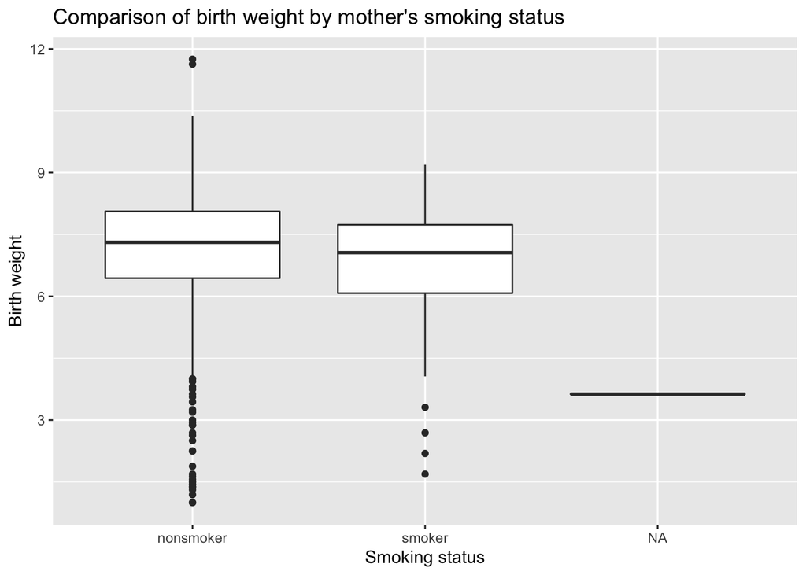

```r
# Plot boxplot of birthweight by mom's smoking status
ggplot(ncbirths, aes(x=habit, y=weight)) +
  geom_boxplot() +
  ylab('Birth weight') +
  xlab('Smoking status') +
  ggtitle("Comparison of birth weight by mother's smoking status")
```

```r
# Numerically summarize birthweight by mom's smoking status
ncbirths %>%
  group_by(habit) %>%
  summarise(mean_bw=mean(weight),
            med_bw=median(weight),
            sd_bw=sd(weight),
            iqr_bw=IQR(weight),
            n_obs=n())
```

```
## # A tibble: 3 x 6
##   habit     mean_bw med_bw sd_bw iqr_bw n_obs
##   <fct>       <dbl>  <dbl> <dbl>  <dbl> <int>
## 1 nonsmoker    7.14   7.31  1.52   1.62   873
## 2 smoker       6.83   7.06  1.39   1.66   126
## 3 <NA>         3.63   3.63 NA      0        1
```

*Next I would move on to EDA relevant to my second question (the regression question). Since this question is about exploring the predictive factors of neonatal birth weight, I would want numeric and visual summaries that could let me explore that before I moved on to formal testing in the regression section.*

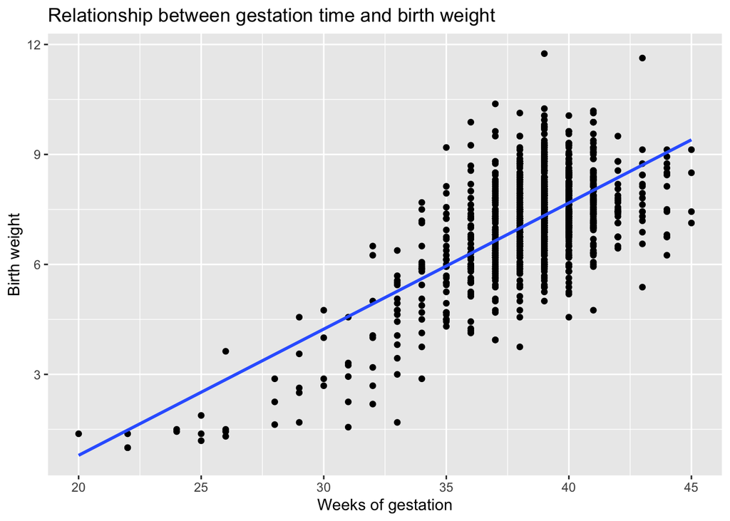

```r
# Plot relationship between gestation time and birth weight
ggplot(ncbirths, aes(x=weeks, y=weight)) +
  geom_point() +
  geom_smooth(method='lm', se=FALSE) +
  ylab('Birth weight') +
  xlab('Weeks of gestation') +
  ggtitle("Relationship between gestation time and birth weight")
```

*Describe positive association between weeks of gestation and birth weight. Note how there are many more observations at 33-45 weeks than <33 weeks, and how the line seems to be an over-prediction for babies born pre-33 weeks.*

*Now I’ll show a couple of examples of how I could look at this relationship while controlling for an additional variable. First, using my smoking status variable from before.*

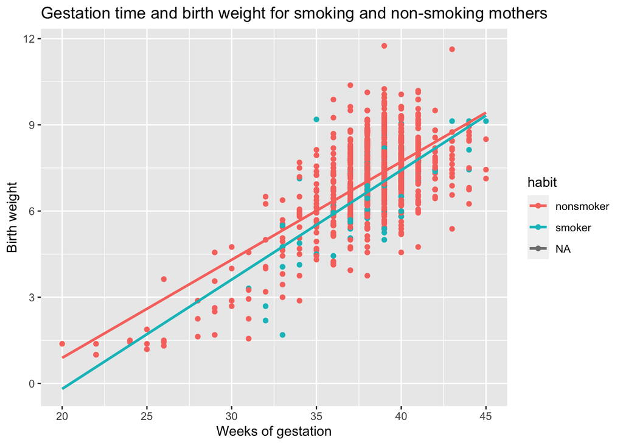

```r
# Plot relationship between gestation time and birth weight, colored by smoking status of mother
ggplot(ncbirths, aes(x=weeks, y=weight, color=habit)) +
  geom_point() +
  geom_smooth(method='lm', se=FALSE, fullrange=TRUE) +
  ylab('Birth weight') +
  xlab('Weeks of gestation') +
  ggtitle("Gestation time and birth weight for smoking and non-smoking mothers")
```

The story told in the above plot is interesting. We see that late in gestation, the average birth weight for smoking and non-smoking mothers appears similar, but that this gap is wider earlier in gestation. It is possible that smoking may inhibit growth early in pregnancy, but as time goes on babies are able to “catch up” in weight gain even if their mother smokes (though of course since this is an observational study we can’t speak to the causality of smoking in observed differences in the relationship between gestation weeks and birth weight).

To put in terms of the fitted lines, the slope of the line for smoking mothers appears larger than the slope for non-smoking mothers; that is, the a one week increase in week seems to lead to a higher increase in weight for babies of smoking mothers than that of non-smoking mothers. However, the starting weight for smoking mothers (i.e. the average weight at 20 weeks) appears smaller.

*Suppose I want to instead show how the relationship between gestation weeks and birth weight varies with mother age (another continuous variable). I could just color by age in my plot, but it’s hard to see anything just by that…*

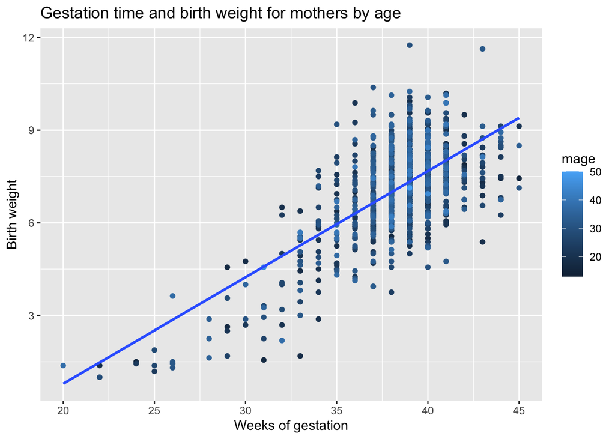

```r
# Plot relationship between gestation time and birth weight, faceted by mother age
ggplot(ncbirths, aes(x=weeks, y=weight, color=mage)) +
  geom_point() +
  geom_smooth(method='lm', se=FALSE, fullrange=TRUE) +
  ylab('Birth weight') +
  xlab('Weeks of gestation') +
  ggtitle("Gestation time and birth weight for mothers by age")
```

*Visually it will be easier to see what’s going on if I bin the `mage` variable.*

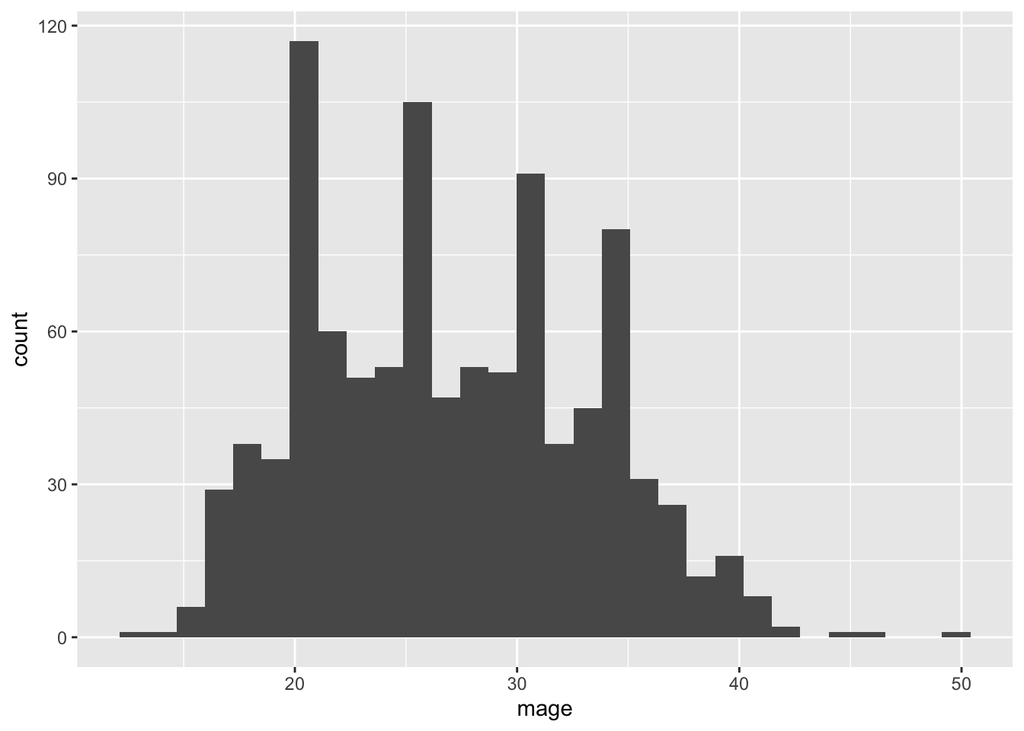

```r
# Show mother age variable
ggplot(ncbirths, aes(x=mage)) +
  geom_histogram()
```

```r
# Create a new categorical variable by binning mother's age
ncbirths <- ncbirths %>%
  mutate(mage_bin=cut(mage,
                      breaks=quantile(ncbirths$mage, prob=c(0,0.25,0.5,0.75,1)),
                      labels=c("very young","youngish","bit older","very old")))
```

*Then I can do the same coloring as before but with color by bin:*

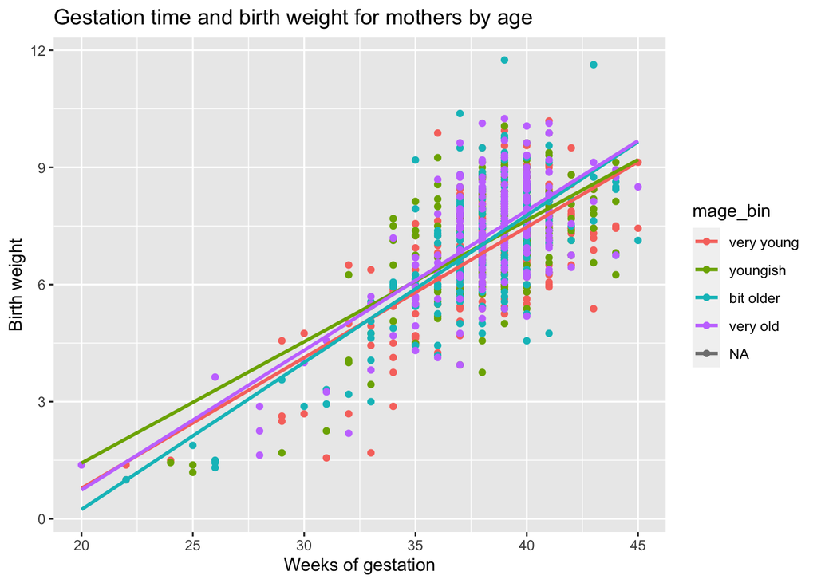

```r
# Plot relationship between gestation time and birth weight, faceted by mother age
ggplot(ncbirths, aes(x=weeks, y=weight, color=mage_bin)) +
  geom_point() +
  geom_smooth(method='lm', se=FALSE, fullrange=TRUE) +
  ylab('Birth weight') +
  xlab('Weeks of gestation') +
  ggtitle("Gestation time and birth weight for mothers by age")
```

*Or I could facet by age:*

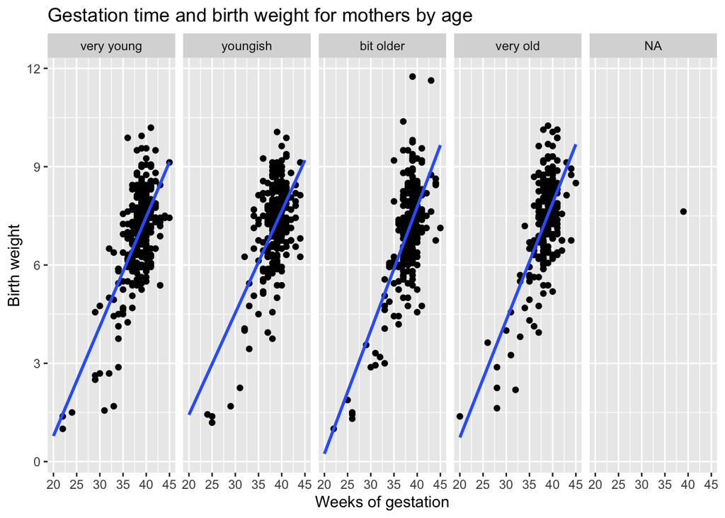

```r
# Plot relationship between gestation time and birth weight, faceted by mother age
ggplot(ncbirths, aes(x=weeks, y=weight)) +
  geom_point() +
  facet_grid(~mage_bin) +
  geom_smooth(method='lm', se=FALSE, fullrange=TRUE) +
  ylab('Birth weight') +
  xlab('Weeks of gestation') +
  ggtitle("Gestation time and birth weight for mothers by age")
```

*I would do the same type of discussion here as for the weight, weeks, and smoking plot, noting that differences seem fairly minimal.*

### Inference

In this section we want to:

- State the null and alternative hypotheses.
- Check necessary conditions.
- Provide test results (p-value and decision) below code used to get this output.
- Interpret results in context of the data.

We consider a hypothesis test of the difference of two means. Our null hypothesis is that the average birth weight for babies is the same for non-smoking and smoking mothers. Our alternative hypothesis is that the average birth weight for babies is different for non-smoking and smoking mothers.

Because the data are a random sample of 1,000 cases from births recorded in NC, independence within and between groups is satisfied. We have $n>30$, however, as we saw in our box plots, there are more outliers than we would expect from normally distributed data (see OIS Ch. 7.3 for a refresher on the conditions for assessing a difference in means). Because of this, we perform inference using simulation-based methods, the bootstrap. Note that in the case that conditions for the theoretical test have been met you could just replace `method="simulation"` with `method="theoretical"` to use theoretical methods.

```r
# Test for the difference of two means
inference(y=weight, x=habit, data=ncbirths,
          type="ht",           # hypothesis test
          statistic="mean",    # interested in mean
          method="simulation", # using bootstrap
          alternative="twosided") # type of alternative
```

[output not shown]

[figure not shown]

In the EDA section, our boxplot and summary statistics showed that non-smoking mothers had babies that were on average slightly heavier at birth than smoking mothers. Here we assess whether this finding is statistically significant. Using the bootstrap, we reject the null hypothesis that the average birth weight for babies is the same for non-smoking and smoking mothers at the 0.05 level ($p=0.03$). Our data provide strong evidence in favor of the alternative hypothesis that the average birth weight for babies is different for non-smoking and smoking mothers, and our data suggest that the direction of the relationship favors non-smoking mothers as birthing heavier babies.

### Regression

_Read assignment statement for more details: https://kelrenmor.github.io/STA101-002/project_files/project_st2_statement._

**Run an Initial “Full Model”, and discuss the output**

```r
# Regress birth weight on various explanatory variables
mod_full = lm(weight ~ mage + mature + weeks + visits + marital + gender + habit + whitemom,
              data = ncbirths)

# Summarize output
summary(mod_full)
```

```
##
## Call:
## lm(formula = weight ~ mage + mature + weeks + visits + marital +
##     gender + habit + whitemom, data = ncbirths)
##
## Residuals:
##     Min      1Q  Median      3Q     Max
## -3.5227 -0.6762 -0.0152  0.6666  4.2431
##
## Coefficients:
##                    Estimate Std. Error t value Pr(>|t|)
## (Intercept)       -6.375307   0.551948 -11.551  < 2e-16 ***
## mage               0.005738   0.008152   0.704  0.48168
## matureyounger mom -0.008632   0.134863  -0.064  0.94898
## weeks              0.336365   0.012327  27.287  < 2e-16 ***
## visits            -0.002501   0.009138  -0.274  0.78436
## maritalmarried     0.237002   0.085235   2.781  0.00553 **
## gendermale         0.376454   0.069081   5.449  6.4e-08 ***
## habitsmoker       -0.341108   0.105083  -3.246  0.00121 **
## whitemomwhite      0.248995   0.081697   3.048  0.00237 **
## ---
## Signif. codes:  0 '***' 0.001 '**' 0.01 '*' 0.05 '.' 0.1 ' ' 1
##
## Residual standard error: 1.083 on 979 degrees of freedom
##   (12 observations deleted due to missingness)
## Multiple R-squared:  0.4737, Adjusted R-squared:  0.4694
## F-statistic: 110.2 on 8 and 979 DF,  p-value: < 2.2e-16
```

*First, talk about the significance:*

For the intercept, and each of the coefficients associated with time of gestation (`weeks`), marital status of mother (`marital`), baby sex (`gender`), mother’s smoking status (`habit`), and mother’s race (`whitemom`), we reject the null hypothesis of the coefficient equaling 0.

*Then, interpret the coefficient values for the significant coefficients:*

We expect a one-week increase in gestation time to lead to an increase in neonatal birth weight of 0.336 pounds, all else held constant. We expect male babies to weigh 0.376 pounds more than female babies, all else held constant. Etc… [you should expand on all significant predictors.]

*Finally, note the R-squared value and interpret in the context of the data (how much variability is explained by these explanatory variables?*

**Split Data into Test and Training Data**

```r
project.data <- ncbirths
n.obs <- dim(project.data)[1]

train.index <- sample(1:n.obs,floor(.8*n.obs),replace=FALSE)  # randomly select 80% of obs for training
project.train <- project.data[train.index,]  # Data for training the model
project.test <- project.data[-train.index,]  # Data for testing the model's accuracy
```

**Perform Backwards Elimination on the Training Data**

First, we copy the single_step_backwards function from the [project statement](https://kelrenmor.github.io/STA101-002/project_files/project_st2_statement).

```r
# Define the single_step_backwards function
# Copy and run this to be able to use the function yourself (DO NOT EDIT)
single_step_backwards <- function(data, response_var, explanatory_vars){
  resp.indx <- which(names(data)==response_var)
  expl.indx <- sapply(explanatory_vars, function(x) which(names(data)==x))
  y <- data[[response_var]]
  X <- data[,expl.indx]
  n.pred <- dim(X)[2]
  if(n.pred > 1){
    full_adjrsq = summary(lm(y~.,data=as.data.frame(X)))$adj.r.squared
    print(paste0("Adjusted R-squared of model including all input explanatory variables: ",
                 round(full_adjrsq,5)))
    print("")
    for(i in 1:n.pred){
      red_adjrsq <- summary(lm(y~.,data=as.data.frame(X[,-i])))$adj.r.squared
      print(paste0("With variable ", names(X)[i]," removed, adj R-squared becomes: ",
                   round(red_adjrsq,5),
                   ifelse(red_adjrsq>full_adjrsq,", an improvement ",", a deterioration "),
                   "from the input model"))
    }
  } else{
    print("Model only contains one variable.")
  }
}
```

Now, we are able to use the `single_step_backwards()` function, and we go through the backward selection process using the metric of $R^2_{adj}$, beginning with all of the variables included in our full model.

```r
single_step_backwards(data = project.train,
                      response_var = "weight",
                      explanatory_vars = c("mage", "mature", "weeks", "visits", "marital",
                                           "gender", "habit", "whitemom") )
```

```
## [1] "Adjusted R-squared of model including all input explanatory variables: 0.49018"
## [1] ""
## [1] "With variable mage removed, adj R-squared becomes: 0.48992, a deterioration from the input model"
## [1] "With variable mature removed, adj R-squared becomes: 0.49083, an improvement from the input model"
## [1] "With variable weeks removed, adj R-squared becomes: 0.07648, a deterioration from the input model"
## [1] "With variable visits removed, adj R-squared becomes: 0.50634, an improvement from the input model"
## [1] "With variable marital removed, adj R-squared becomes: 0.48428, a deterioration from the input model"
## [1] "With variable gender removed, adj R-squared becomes: 0.47451, a deterioration from the input model"
## [1] "With variable habit removed, adj R-squared becomes: 0.48545, a deterioration from the input model"
## [1] "With variable whitemom removed, adj R-squared becomes: 0.48739, a deterioration from the input model"
```

We see above that $R^2_{adj}$ increases when we remove either the `mature` or the `visits` variable from the model. Since the resulting $R^2_{adj}$ is higher when `visits` is removed, we drop this as our first step in the backward selection process. We now take another single step having removed `visits` from the list of explanatory variables.

```r
single_step_backwards(data = project.train,
                      response_var = "weight",
                      explanatory_vars = c("mage", "mature","weeks", "marital",
                                           "gender", "habit", "whitemom") )
```

```
## [1] "Adjusted R-squared of model including all input explanatory variables: 0.50634"
## [1] ""
## [1] "With variable mage removed, adj R-squared becomes: 0.50585, a deterioration from the input model"
## [1] "With variable mature removed, adj R-squared becomes: 0.50694, an improvement from the input model"
## [1] "With variable weeks removed, adj R-squared becomes: 0.0659, a deterioration from the input model"
## [1] "With variable marital removed, adj R-squared becomes: 0.50135, a deterioration from the input model"
## [1] "With variable gender removed, adj R-squared becomes: 0.49166, a deterioration from the input model"
## [1] "With variable habit removed, adj R-squared becomes: 0.50182, a deterioration from the input model"
## [1] "With variable whitemom removed, adj R-squared becomes: 0.50357, a deterioration from the input model"
```

We see above that $R^2_{adj}$ increases when we remove the `mature` variable from the model, and the removal of any other variable in this step would decrease $R^2_{adj}$. Therefore, we drop this as our second step in the backward selection process. We now take another single step having removed `mature` from the list of explanatory variables.

```r
single_step_backwards(data = project.train,
                      response_var = "weight",
                      explanatory_vars = c("mage", "weeks", "marital",
                                           "gender", "habit", "whitemom") )
```

```
## [1] "Adjusted R-squared of model including all input explanatory variables: 0.50694"
## [1] ""
## [1] "With variable mage removed, adj R-squared becomes: 0.506, a deterioration from the input model"
## [1] "With variable weeks removed, adj R-squared becomes: 0.067, a deterioration from the input model"
## [1] "With variable marital removed, adj R-squared becomes: 0.50168, a deterioration from the input model"
## [1] "With variable gender removed, adj R-squared becomes: 0.49226, a deterioration from the input model"
## [1] "With variable habit removed, adj R-squared becomes: 0.50241, a deterioration from the input model"
## [1] "With variable whitemom removed, adj R-squared becomes: 0.50418, a deterioration from the input model"
```

Now the removal of any individual variable would lead to a decrease in $R^2_{adj}$ relative to the model including all input explanatory variables, i.e. a deterioration in performance. So we stop here and consider this our “Final Model”.

**Show model output for “Final Model”**

```r
# Regress birth weight on the kept explanatory variables using TRAINING DATA
model.best = lm(weight ~ mage + weeks + marital + gender + habit + whitemom,
               data = project.train)

# Summarize output
summary(model.best)
```

```
##
## Call:
## lm(formula = weight ~ mage + weeks + marital + gender + habit +
##     whitemom, data = project.train)
##
## Residuals:
##     Min      1Q  Median      3Q     Max
## -3.2658 -0.6788 -0.0214  0.6633  4.2459
##
## Coefficients:
##                 Estimate Std. Error t value Pr(>|t|)
## (Intercept)    -6.974576   0.537891 -12.967  < 2e-16 ***
## mage            0.010786   0.006825   1.580  0.11446
## weeks           0.348402   0.013115  26.565  < 2e-16 ***
## maritalmarried  0.279763   0.091165   3.069  0.00222 **
## gendermale      0.379384   0.076625   4.951 9.02e-07 ***
## habitsmoker    -0.328466   0.114363  -2.872  0.00419 **
## whitemomwhite   0.188004   0.089927   2.091  0.03688 *
## ---
## Signif. codes:  0 '***' 0.001 '**' 0.01 '*' 0.05 '.' 0.1 ' ' 1
##
## Residual standard error: 1.078 on 789 degrees of freedom
##   (4 observations deleted due to missingness)
## Multiple R-squared:  0.5107, Adjusted R-squared:  0.5069
## F-statistic: 137.2 on 6 and 789 DF,  p-value: < 2.2e-16
```

**Show and interpret diagnostic plots – fitted vs. residuals, normal probability (QQ) plot, histogram of residuals.**

*See labs 7 and 8 for examples of this.*

**Provide parameter interpretation – summarize the relationship between the response variable and the explanatory variables in the model.**

*As with the full model, interpret the parameters in the context of the data (using proper units). See labs 7 and 8, and OIS book Ch 8 and 9 for examples of this. See [this resource](https://data.library.virginia.edu/interpreting-log-transformations-in-a-linear-model/) if you have log transformed response and/or explanatory variables.*

**Compute the RMSE and interpret the value.**

```r
predictions.test <- predict(model.best,project.test)
y <- project.test$weight
mse <- mean((y-predictions.test)^2, na.rm=TRUE)
(rmse <- sqrt(mse))
```

```
## [1] 1.099359
```

The average difference between our model’s predictions of neonatal birthweight and the actual observed neonatal birth weights is 1.1 pounds in the test data.

**Include a prediction for a new observation and interpret the prediction interval correctly.**

```r
# Look at first few rows of the test data set.
head(project.test %>% select(mage, weeks, marital, gender, habit, whitemom))
```

```
## # A tibble: 6 x 6
##    mage weeks marital     gender habit     whitemom
##   <int> <int> <fct>       <fct>  <fct>     <fct>
## 1    15    37 not married male   nonsmoker not white
## 2    15    35 not married male   nonsmoker not white
## 3    16    45 not married male   nonsmoker white
## 4    16    38 not married female smoker    white
## 5    17    40 not married male   nonsmoker not white
## 6    17    35 not married male   nonsmoker not white
```

We will predict the nenatal birth weight for a male infant born to a 15 year old (yikes!) nonsmoking, non-white unmarried woman after 37 weeks of gestation [reading off of the first row of this data set].

```r
# Get prediction interval for first baby in test set
predict(model.best, project.test[1,], interval="predict")
```

```
##        fit      lwr      upr
## 1 6.457476 4.331358 8.583595
```

We predict that the neonatal birth weight (under the above stated conditions) will be 6.46 pounds, and we are 95% confident that this value will be between 4.33 and 8.58 pounds.